# Predicting Lung Cancer Survival 2022

Courtney Van Den Elzen

Jan 30th, 2023

### Libraries

```r
# data cleaning and manipulation tools
library(tidyverse)

# machine learning tools
library(caret)

# Survival analysis
library(tidymodels)
library(censored)
library(glmnet)
```

### Data

```r
# Clinical data:
# (1) ID - patient identifier [1-190]
# (2) Outcome - alive/dead ["Alive"/"Dead"]
# (3) Survival.months - followup time (length of time at which outcome was assessed) [9.0-71.0]
# (4) Age - patient age at diagnosis in years [56-84]
# (5) Grade - tumor grade [1-4 or missing (9 = missing)]
# (6) Num.Primaries - number of primary tumors
# (7) T - tumor stage (I ASSUMED THIS WAS THE FINAL STAGE)
# (8) N - number of metastasis to lymph nodes
# (9) M - number of distance metastases
# (10) Radiation - whether the patient had radiation (5 = yes, 0 = no)
# (11) Stage - Stage at diagnosis
# (12) Primary.Site - Location of primary tumor
# (13) Histology - type of tumor (microscopic structure)
# (14) Tumor.Size - size at diagnosis
# (15) Num.Mutated.Genes - number of genetic mutations found in tumor
# (16) Num.Mutations - number of genes with mutation
clindat <- read_csv("./clinical.csv")
# (1) ID - Patient ID
# (2) Gene - Name of mutated gene
genodat <- read_csv("./genomics.csv")
```

**1. Please walk us through how you cleaned up this dataset. Do you see any interesting trends?**

For these datasets, I cleaned and reorganized the data using several steps. Firstly, I loaded both the clinical and genomics data into R and familiarized myself with the columns of both data frames, including their biological interpretation and expected values and types.

For the genomics data, I first checked for typos and changed the datatypes to factors. I then re-worked the dimensions of the dataset using pivot_wider() such that each column was a dummy variable encoding for presence of a mutation in a specific gene and each row was one patient. Since not every patient had a mutation, there were a few missing patient IDs. I used full_join() to add rows for these patients to the genomics data. I was then able to fill all NAs in as 0s for proper dummy coding. I then used full_join to join the clinical and genomics datasets so that both the gene mutation data and the other clinical variables could be used as features in the models.

### Clean Data: Clinical

```r
clindat_clean <-

     clindat %>%

     # correct data types
     dplyr::mutate(ID = as.factor(ID),
                   Grade = as.integer(Grade),
                   Survival.Months = as.integer(Survival.Months),
                   Radiation = as.factor(Radiation),
                   Num.Primaries = as.factor(Num.Primaries),
                   Num.Mutated.Genes = as.integer(Num.Mutated.Genes),
                   Num.Mutations = as.integer(Num.Mutations)) %>%

     # rename to avoid built-in function incompatibilities
     dplyr::rename(Tumor.Stage = "T") %>%

     # clean data, add NAs where needed, change coding for clarity
     dplyr::mutate(Grade = na_if(Grade, 9),
                   Tumor.Stage = as.factor(na_if(Tumor.Stage, "UNK")),
                   N = as.numeric(na_if(N, "NULL")),
                   M = as.numeric(na_if(M, "NULL")),

                   # assuming that 0 means "no" here
                   Radiation =
                        as.factor(
                             case_when(Radiation == 0 ~ "no",
                                       Radiation == 5 ~ "yes")),

                   # change NULL to NA so R recognizes it.
                   Tumor.Size =
                        as.numeric(
                             na_if(Tumor.Size, "NULL")),

                   # assuming these are the final tumor sizes.
                   # recoded levels to match the coding in "Tumor.Stage"
                   Stage =
                        as.factor(
                             case_when(Stage == "IV" ~ "4",
                                       Stage == "IIIA" ~ "3a",
                                       Stage == "IA" ~ "1a",
                                       Stage == "IVB" ~ "4b",
                                       Stage == "IIA" ~ "2a",
                                       Stage == "IIIB" ~ "3b",
                                       Stage == "IIB" ~ "2b",
                                       Stage == "IB" ~ "1b",
                                       Stage == "1B" ~ "1b")),

                   # typo
                   Primary.Site =
                        as.factor(
                             case_when(
                                  Primary.Site == "Righ Upper Lobe" ~ "Right Upper Lobe",
                                  TRUE ~ Primary.Site))) %>%

     dplyr::mutate(Outcome = case_when(Outcome == "Alive" ~ 0,
                                       Outcome == "Dead" ~ 1))

clindat
```

| ID | Outcome | Survival.Months | Age | Grade | Num.Primaries | T | N | M | Radiation | Stage | Primary.Site | Histology | Tumor.Size | Num.Mutated.Genes | Num.Mutations |
| --- | --- | --- | --- | --- | --- | --- | --- | --- | --- | --- | --- | --- | --- | --- | --- |
| 1 | Alive | 9.0 | 67 | 4 | 0 | UNK | 2 | NULL | 0 | IV | Left Lower Lobe | Squamous cell carcinoma | 1.4 | 8 | 8 |
| 2 | Dead | 19.0 | 73 | 2 | 0 | UNK | 2 | 0 | 5 | IV | Right Upper Lobe | Adenocarcinoma | NULL | 2 | 2 |
| 3 | Dead | 13.0 | 72 | 3 | 0 | 2 | 2 | 0 | 0 | IIIA | Right Upper Lobe | Adenocarcinoma | 1.5 | 1 | 1 |
| 4 | Dead | 15.0 | 69 | 9 | 1 | 1a | 0 | 1 | 0 | IA | Right Upper Lobe | Adenocarcinoma | NULL | 4 | 4 |
| 5 | Dead | 10.0 | 76 | 9 | 0 | UNK | NULL | NULL | 0 | IIIA | Left Hilar | Large-cell carcinoma | NULL | 3 | 3 |
| 6 | Dead | 11.0 | 62 | 9 | 0 | 3 | 2 | NULL | 0 | IVB | Left Hilar | Adenocarcinoma | NULL | 4 | 5 |
| 7 | Dead | 13.0 | 72 | 2 | 0 | 4 | NULL | 1 | 5 | IV | Right Hilar | Adenocarcinoma | 5.5 | 4 | 4 |
| 8 | Dead | 13.0 | 72 | 2 | 0 | 3 | NULL | 0 | 0 | IIA | Right Upper Lobe | Adenocarcinoma | 2 | 2 | 2 |
| 9 | Dead | 19.0 | 72 | 9 | 0 | 4 | NULL | 0 | 0 | IIA | Right Upper Lobe | Squamous cell carcinoma | 2 | 3 | 3 |
| 10 | Alive | 9.0 | 83 | 3 | 0 | UNK | NULL | NULL | 5 | IV | Left Upper Lobe | Squamous cell carcinoma | NULL | 3 | 3 |

[output cut: 180 more lines]

### Clean Data: Genomic Data

```r
# add a data frame of just IDs, this allows us to add rows for those patients
# where no mutation was found
ID_frame <-
     data.frame(ID = 1:190) %>%
     dplyr::mutate(ID = as.factor(ID))

# change both columns to factors.
genodat_clean <-

     genodat %>%

     # add this dummy column for pivot_wider
     dplyr::mutate(values = 1) %>%

     # change orientation of data frame so each gene is a column
     # (allows for joining with clinical data)
     tidyr::pivot_wider(names_from = Gene, values_from = values) %>%

     # change ID column type for compatibility with clindat
     dplyr::mutate(ID = as.factor(ID))

# join with ID_frame to add patient IDs with no mutations
# and replace NAs with 0s.
genodat_clean2 <-
     dplyr::full_join(ID_frame, genodat_clean) %>%
     dplyr::mutate_if(is.numeric, ~replace(., is.na(.), 0))
# Join with clinical data (each mutation can now be used as a feature)
cgdat_full <-
     dplyr::full_join(clindat_clean, genodat_clean2)
cgdat_full
```

| ID | Outcome | Survival.Months | Age | Grade | Num.Primaries | Tumor.Stage | N | M | Radiation | Stage | Primary.Site | Histology | Tumor.Size | Num.Mutated.Genes | Num.Mutations | AKT1 | ALK_Col1 | ALK_Col2 | APC | ATM_Col1 | ATM_Col2 | BRAF | CCND2 | CDKN2A | CTNNB1 | DNMT3A | EGFR | ERBB3 | ERBB4 | … |
| --- | --- | --- | --- | --- | --- | --- | --- | --- | --- | --- | --- | --- | --- | --- | --- | --- | --- | --- | --- | --- | --- | --- | --- | --- | --- | --- | --- | --- | --- | --- |
| 1 | 0 | 9 | 67 | 4 | 0 | NA | 2 | NA | no | 4 | Left Lower Lobe | Squamous cell carcinoma | 1.4 | 8 | 8 | 1 | 0 | 0 | 0 | 0 | 0 | 0 | 1 | 0 | 0 | 0 | 1 | 0 | 0 | … |
| 2 | 1 | 19 | 73 | 2 | 0 | NA | 2 | 0 | yes | 4 | Right Upper Lobe | Adenocarcinoma | NA | 2 | 2 | 0 | 0 | 0 | 0 | 0 | 0 | 0 | 0 | 0 | 0 | 0 | 0 | 0 | 0 | … |
| 3 | 1 | 13 | 72 | 3 | 0 | 2 | 2 | 0 | no | 3a | Right Upper Lobe | Adenocarcinoma | 1.5 | 1 | 1 | 0 | 0 | 0 | 0 | 0 | 0 | 0 | 0 | 0 | 0 | 0 | 0 | 0 | 0 | … |
| 4 | 1 | 15 | 69 | NA | 1 | 1a | 0 | 1 | no | 1a | Right Upper Lobe | Adenocarcinoma | NA | 4 | 4 | 0 | 0 | 0 | 0 | 0 | 0 | 0 | 0 | 1 | 0 | 0 | 0 | 0 | 0 | … |
| 5 | 1 | 10 | 76 | NA | 0 | NA | NA | NA | no | 3a | Left Hilar | Large-cell carcinoma | NA | 3 | 3 | 0 | 0 | 0 | 0 | 0 | 0 | 0 | 0 | 0 | 0 | 0 | 0 | 0 | 0 | … |
| 6 | 1 | 11 | 62 | NA | 0 | 3 | 2 | NA | no | 4b | Left Hilar | Adenocarcinoma | NA | 4 | 5 | 0 | 0 | 0 | 1 | 0 | 0 | 0 | 0 | 0 | 0 | 0 | 0 | 0 | 0 | … |
| 7 | 1 | 13 | 72 | 2 | 0 | 4 | NA | 1 | yes | 4 | Right Hilar | Adenocarcinoma | 5.5 | 4 | 4 | 0 | 0 | 0 | 0 | 0 | 0 | 0 | 0 | 0 | 0 | 0 | 0 | 0 | 0 | … |
| 8 | 1 | 13 | 72 | 2 | 0 | 3 | NA | 0 | no | 2a | Right Upper Lobe | Adenocarcinoma | 2.0 | 2 | 2 | 0 | 0 | 0 | 0 | 0 | 0 | 0 | 0 | 0 | 0 | 0 | 0 | 0 | 0 | … |
| 9 | 1 | 19 | 72 | NA | 0 | 4 | NA | 0 | no | 2a | Right Upper Lobe | Squamous cell carcinoma | 2.0 | 3 | 3 | 0 | 0 | 0 | 0 | 0 | 0 | 0 | 0 | 1 | 0 | 0 | 0 | 0 | 0 | … |
| 10 | 0 | 9 | 83 | 3 | 0 | NA | NA | NA | yes | 4 | Left Upper Lobe | Squamous cell carcinoma | NA | 3 | 3 | 0 | 0 | 0 | 0 | 0 | 0 | 0 | 0 | 0 | 0 | 0 | 0 | 0 | 0 | … |

[output cut: 180 more lines]

** 2. Tell us how you decided which features to use for your model. Are there any new features it might be productive to engineer from the current features? **

[output not shown]

** 3. Which algorithm did you use for the prediction and why? **

```
I used a cox proportional hazards model because I believed it would be the most accurate model for predicting the time to an event. This model is not one I have worked with before and I underestimated the complexity of getting predictions out on the scale of months (as opposed to a relative risk/hazard estimate). Additionally, this was my first time using tidymodels for fitting predictive models.
```

### Split the data into test and train sets

```r
trainIndex <- caret::createDataPartition(cgdat_full$Outcome, p = .8,
                                         list = FALSE,
                                         times = 1)

cgdat_train <- cgdat_full[trainIndex,]
cgdat_test <- cgdat_full[-trainIndex,]
```

### Modeling survival: Cox Regression

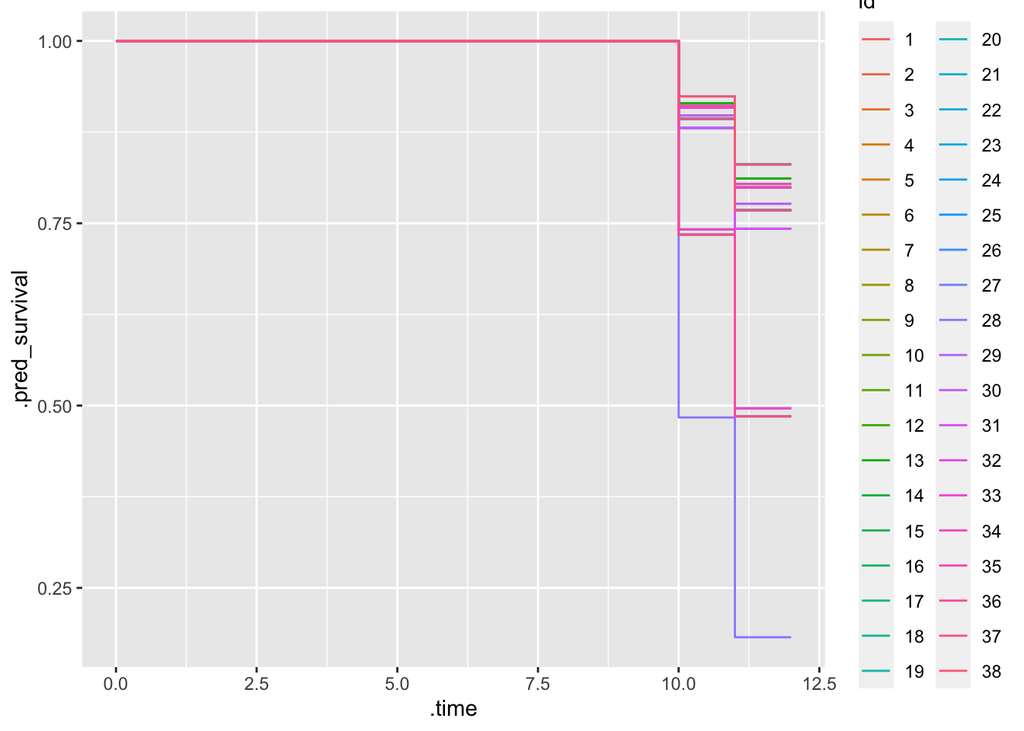

```r
# Use parsnip + glmnet packages to set up the cox models
# here we used the default settings set by the glmnet package
cox_spec_glmnet <- parsnip::proportional_hazards(penalty = 0.1) %>%
    set_engine("glmnet")


# glmnet cox model
coxmod_fit_glmnet <-
  fit(cox_spec_glmnet,
      Surv(Survival.Months, Outcome, type = "right") ~ Stage + Age + Radiation + Histology + Num.Primaries + Num.Mutated.Genes,
      data = cgdat_train)


# generating predictions of survival to 12 months
coxmod_glmnet_pred <-
  predict(coxmod_fit_glmnet,
          new_data = cgdat_test,
          type = "survival", time = seq(0, 12, 1))

# reformatting predictions
coxmod_glmnet_pred <-
  coxmod_glmnet_pred %>%
  mutate(id = factor(1:nrow(cgdat_test))) %>%
  unnest(cols = .pred)

# plot the predicted survival to 12 months
coxmod_glmnet_pred %>%
  ggplot(aes(x = .time, y = .pred_survival, col = id)) +
  geom_step()
```

** 4. How did you assess the predictive model’s quality? Summarize your findings. **

[output not shown]

** 5. Next steps? What might you do with more time or access to additional data or expertise? **

If given more time:

1. I would further familiarize myself with the tidymodels package. I realized pretty early into this assignment that the caret package, the package I have previously used to fit predictive models, does not have support for cox models. Since I believed cox models were the right tool for the job here, I then attempted to use the survival package alone and realized that I could not get actual survival time estimates using the predict function from that package. I found a vignette from the tidymodels authors on predicting survival time from cox models and I used that to find predictions for survival to 12 months, but I would need more time to make sure that the underlying assumptions and hyperparameter values were tuned correctly for this dataset.
2. I would apply more complex algorithms for feature selection and assessing predictive performance. In particular I would use LOO cross-validation to assess model performance instead of a single test-train split. I would also consider an automated algorithm for choosing the best set of features, including consideration of individual gene mutation outcome variables.